# Land Change Estimation

Spatial & Modelling Check of Submitted Land Cover Change Estimates & Activity Data Methods

Author

Winrock International

Published

December 8, 2025

### Environment Setup

To install additional dependencies and drivers for accessing ESRI-formatted data submitted by client, ensure the new GDAL library (3.12) is enabled and linked to R’s and python’s spatial libraries and packages. This is a bit of a headache because `sf` and related packages come bundled as binaries that pre-install a legacy GDAL 3.8 (& GEOS), and the symlinks and dependency tests of those `sf` installations did not allow changing this to machine’s global GDAL Installation steps were saved here in this [gist](https://gist.github.com/seamusrobertmurphy/a386ce3a022bf51c4795a402fb5c754b).

Please note that `sf::sf_use_s2(use_s2 = TRUE)` is applied in setup chunk below, which means this workflow’s computations are based in a spherical geometric plane, which is critical accuracy concern for larger areas like Bolivia extent. Earth engine platforms switch without explicitly indicating between pseudomercator (3857) and geographic projections (4326), which also implies but does not confirm different geometric ellipsoid planes are applied. Advisable to highlight this when discuss discrepancies with estimates derived in code.earth.engine.

```r
#install.packages(c("devtools", "easypackages"))
easypackages::packages(
  "bslib",
  "cols4all", "covr", "cowplot",
  "dendextend", "digest","DiagrammeR","dtwclust", "downlit", "devtools",
  "e1071", "exactextractr","elevatr",
  "FNN", "future", "forestdata", "flextable",
  "gdalcubes", "gdalUtilities", "geojsonsf", "geos", "geodata", "ggplot2", "ggstats",
  "ggspatial", "ggmap", "ggplotify", "ggpubr", "ggrepel", "giscoR",
  "hdf5r", "httr", "httr2", "htmltools",
  "janitor", "jsonlite",
  "kableExtra", "kohonen",
  "leaflet.providers", "leafem", "libgeos","luz","lwgeom", "leaflet", "leafgl",
  "mapedit", "mapview", "maptiles", "methods", "mc2d",
  "ncdf4", "nnet",
  "openxlsx", "parallel", "plotly",
  "proj4", "PROJ", "performanceEstimation",
  "randomForest", "rasterVis", "raster", "Rcpp", "RcppArmadillo",
  "RcppCensSpatial","rayshader", "RcppEigen", "RcppParallel",
  "RColorBrewer", "reactable", "rgl", "rsconnect","RStoolbox", "rts", "reproj",
  "s2", "sf", "scales", "sits","spdep", "stars", "stringr","supercells",
  "terra", "testthat", "tidyverse", "tidyterra","tools",
  "tmap", "tmaptools", "terrainr", "tibble",
  "xgboost",
  "webshot", "webshot2",
  prompt = F)


options(htmltools.dir.version = F, htmltools.preserve.raw = F)
devtools::install_github("ltorgo/performanceEstimation",ref="develop")
knitr::opts_chunk$set(
  echo = TRUE,
  message = FALSE,
  warning = FALSE,
  error = FALSE,
  comment = NA,
  tidy.opts = list(width.cutoff = 60),
  dev = "png",
  dpi = 300
  )

# Configure webshot2
knitr::opts_knit$set(rmarkdown.pandoc.to = "docx")
# Configure geometric plane
mapview::mapviewOptions(fgb = FALSE)
sf::sf_use_s2(use_s2 = TRUE) # spherical geometries for massive areas
#sf::sf_use_s2(use_s2 = FALSE) # non-spherical geometries for smaller extents
terra::terraOptions(memfrac=0.9, tempdir = "./temp")
sf::sf_extSoftVersion()
```

```
NA           GEOS           GDAL         proj.4 GDAL_with_GEOS     USE_PROJ_H
NA       "3.14.1"       "3.12.0"        "9.7.1"         "true"         "true"
NA           PROJ
NA        "9.7.1"
```

## Objective

This report serves to document methods used to validate Charagua’s Activity Data methods, performance metrics, and land change estimates reported in ART-TREES carbon offset program’s in Section 10.4 of submitted TREES Registration Document [(TRD)](https://drive.google.com/file/d/1UZ5yOzoruqN32X140BeFxLpW-c7JZ2RA/view?usp=drive_link) and supporting technical report of Bolivia’s [National Forest Emissions Level Methodology](https://drive.google.com/file/d/1IIAjtEqeAgQJQT_WrhCcF-FjtODlv4dV/view?usp=drive_link).

To verify compliance and accuracy of these program submissions, we attempted to reproduce emissions estimates (TRD, Table 10.6.2) and specifically their upstream area estimates found in tabsheet called `Activity Data` in submitted [workbooks](https://drive.google.com/drive/folders/1ewn9V60x_dorn-sz8Ol9HmTXo0femglu?usp=drive_link), as shown screenshot below table.

| Category | Name | Description | Source/Location |
| --- | --- | --- | --- |
|  | [ART-TREES_CHAR_v1.gdb](https://winrockintl.sharepoint.com/:f:/s/Collab/Eco/IgCtFRMHC-OcR7GnbXkuUBEzATvS8x8p5ucwz4QjfGv5J_c?e=hSEslZ) |  |  |
|  | [/Bolivia/](https://winrockintl.sharepoint.com/:f:/s/Collab/Eco/IgDyrFrkpTkYR4VZD0Fp0FozATR4ZfY40-2gmg6VjuHaXLs?e=9siIdq) |  |  |
| Program Document | [CHAR_TREES-Registration-Document_v2.pdf](https://drive.google.com/file/d/1UZ5yOzoruqN32X140BeFxLpW-c7JZ2RA/view?usp=drive_link) | TREES Registration Document (TRD) | Client Submission ([Received 2025-10-28](https://winrockintl.sharepoint.com/:f:/s/Collab/Eco/IgBw_APiqEiTRoRciFjq3u8-ATvoaYLFJWG2ER2xn0xKhlE?e=TQQ0Uk)) |
| Program Workbook | [CHAR_MC 4 estimating ER from forests_base_sheet_v1.xlsx](https://docs.google.com/spreadsheets/d/1O_UMyhDA7_-KjT1I6LrqCG0xWBH0E58Q/edit?usp=sharing&ouid=111043860473625797405&rtpof=true&sd=true) | `Activity Data` Tabsheet | Client Submission ([Received 2025-11-22](https://drive.google.com/drive/folders/1ewn9V60x_dorn-sz8Ol9HmTXo0femglu?usp=drive_link)) |
| Program Methodology | [BO_NREF_v3.0_20240108.pdf](https://winrockintl.sharepoint.com/:b:/s/Collab/Eco/IQBGXAQJFQvQTJDRpcTX5H_uAV08gI6bmJnYbkFyOyaV1ng?e=LF8Hcm) | Technical Report | Client Submission ([Received 2025-10-28](https://winrockintl.sharepoint.com/:f:/s/Collab/Eco/IgBw_APiqEiTRoRciFjq3u8-ATvoaYLFJWG2ER2xn0xKhlE?e=TQQ0Uk)) |
| Program Methodology | [Especificaciones contabilidad ER Charagua….docx](https://docs.google.com/document/d/1oxl1BQpF4s-S1gX5BgloBBFZEG5IE4Co/edit?usp=share_link&ouid=111043860473625797405&rtpof=true&sd=true) | Technical Memo | Client Submission ([Received 2025-11-22](https://drive.google.com/drive/folders/1ewn9V60x_dorn-sz8Ol9HmTXo0femglu?usp=drive_link)) |
| Dataset | [FAO Agro-Ecological Zones](https://www.fao.org/faostat/en/#data/GI/metadata) | Tier-1 Strata (Global) | FAO-GEZ (2012); [DOI](https://www.gaez.iiasa.ac.at/docs/GAEZ_Model_Documentation.pdf); [Repo](https://www.fao.org/faostat/en/#data/GI/metadata) |
| Dataset Documentation | MapBiomass Methodology Report |  | RAISG [(2022)](https://amazonia.mapbiomas.org/wp-content/uploads/sites/10/2023/08/ATBD_General_MapBiomas_Amazonia_4.0.pdf#page=22) |

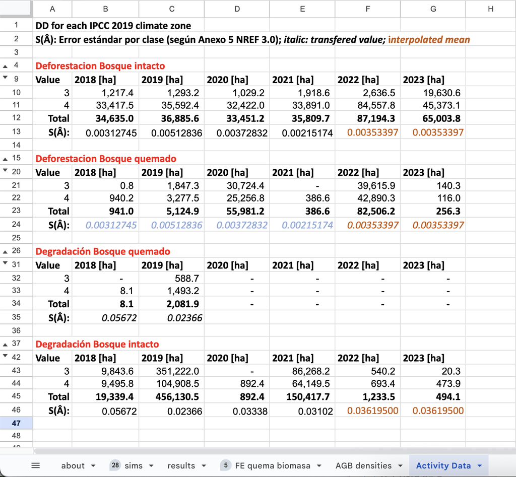

## Method

### Import Project Data

```r
# check OpenGDB drivers available for handling
sf::st_drivers()["OpenFileGDB",]
sf::sf_extSoftVersion()

# unpack filegeodatabase and import client submissions
winrock_path = "~/OneDrive - Winrock International Institute for Agricultural Development/20073 - DESNZ LEAF TA/Working Files/Technical Assistance/Consultants/Bolivia/"
local_path = "/Volumes/TOSHIBA_EXT/Winrock/Bolivia/LULC/"
gdb_path   = file.path(winrock_path, "Spatial Data", "GDB", "ART-TREES_CHAR_v1.gdb")

# subds => positive integer or character to select sub-dataset (GDAL native)
aoi_project = sf::st_read(gdb_path, layer="Charagua")
aoi_cropper = sf::st_transform(aoi_project, "EPSG:4326") # ee & ellipsoid ready
crs_project = sf::st_crs(aoi_project)
Deforestacion_bosque_intacto_2018 = terra::rast(gdb_path, subds=2) |> raster::raster()
Deforestacion_bosque_intacto_2020 = terra::rast(gdb_path, subds=3) |> raster::raster()
Deforestacion_bosque_intacto_2021 = terra::rast(gdb_path, subds=4) |> raster::raster()
Deforestacion_bosque_intacto_2022 = terra::rast(gdb_path, subds=5) |> raster::raster()
Deforestacion_bosque_intacto_2023 = terra::rast(gdb_path, subds=6) |> raster::raster()
Deforestacion_bosque_intacto_2019 = terra::rast(gdb_path, subds=7) |> raster::raster()
Deforestacion_bosque_quemado_2018 = terra::rast(gdb_path, subds=8) |> raster::raster()
Deforestacion_bosque_quemado_2020 = terra::rast(gdb_path, subds=9) |> raster::raster()
Deforestacion_bosque_quemado_2021 = terra::rast(gdb_path, subds=10) |> raster::raster()
Deforestacion_bosque_quemado_2022 = terra::rast(gdb_path, subds=11) |> raster::raster()
Deforestacion_bosque_quemado_2023 = terra::rast(gdb_path, subds=12) |> raster::raster()
Deforestacion_bosque_quemado_2019 = terra::rast(gdb_path, subds=13) |> raster::raster()
Degradacion_bosque_intacto_2018 = terra::rast(gdb_path, subds=14) |> raster::raster()
Degradacion_bosque_intacto_2020 = terra::rast(gdb_path, subds=15) |> raster::raster()
Degradacion_bosque_intacto_2021 = terra::rast(gdb_path, subds=16) |> raster::raster()
Degradacion_bosque_intacto_2022 = terra::rast(gdb_path, subds=17) |> raster::raster()
Degradacion_bosque_intacto_2023 = terra::rast(gdb_path, subds=18) |> raster::raster()
Degradacion_bosque_intacto_2019 = terra::rast(gdb_path, subds=19) |> raster::raster()
Degradacion_bosque_quemado_2018 = terra::rast(gdb_path, subds=20) |> raster::raster()
Degradacion_bosque_quemado_2020 = terra::rast(gdb_path, subds=21) |> raster::raster()
Degradacion_bosque_quemado_2021 = terra::rast(gdb_path, subds=22) |> raster::raster()
Degradacion_bosque_quemado_2022 = terra::rast(gdb_path, subds=23) |> raster::raster()
Degradacion_bosque_quemado_2023 = terra::rast(gdb_path, subds=24) |> raster::raster()
Degradacion_bosque_quemado_2019 = terra::rast(gdb_path, subds=25) |> raster::raster()
CHAR_AGB_ppx                                = terra::rast(gdb_path, subds=26) |> raster::raster()
CHAR_AGB_pha                                = terra::rast(gdb_path, subds=27) |> raster::raster()
GAEZ_pct_harvested_2010         = terra::rast(gdb_path, subds=28) |> raster::raster()
CHAR_AGB_pha_ICESat2            = terra::rast(gdb_path, subds=29) |> raster::raster()
CHAR_AGB_pha_bosque_ICESat2 = terra::rast(gdb_path, subds=30) |> raster::raster()

STACK_submissions = raster::brick(
    Deforestacion_bosque_intacto_2018,
    Deforestacion_bosque_intacto_2019,
    Deforestacion_bosque_intacto_2020,
    Deforestacion_bosque_intacto_2021,
    Deforestacion_bosque_intacto_2022,
    Deforestacion_bosque_intacto_2023,
    Deforestacion_bosque_intacto_2018,
    Deforestacion_bosque_quemado_2019,
    Deforestacion_bosque_quemado_2020,
    Deforestacion_bosque_quemado_2021,
    Deforestacion_bosque_quemado_2022,
    Deforestacion_bosque_quemado_2023,
    Deforestacion_bosque_quemado_2018,
    Degradacion_bosque_intacto_2018,
    Degradacion_bosque_intacto_2019,
    Degradacion_bosque_intacto_2020,
    Degradacion_bosque_intacto_2021,
    Degradacion_bosque_intacto_2022,
    Degradacion_bosque_intacto_2023,
    Degradacion_bosque_quemado_2018,
    Degradacion_bosque_quemado_2019,
    Degradacion_bosque_quemado_2020,
    Degradacion_bosque_quemado_2021,
    Degradacion_bosque_quemado_2022,
    Degradacion_bosque_quemado_2023,
    CHAR_AGB_ppx,
    CHAR_AGB_pha,
    GAEZ_pct_harvested_2010,
    CHAR_AGB_pha_ICESat2,
    CHAR_AGB_pha_bosque_ICESat2
    )

# derive country aoi and save to local copy
aoi_country = geodata::gadm(country="BOL", level=0, path="./Assets/SHP") |> sf::st_as_sf()
aoi_state  = geodata::gadm(country="BOL", level=1, path="./Assets/SHP") |> sf::st_as_sf()

# save outputs to local disk for memmory-efficient workflow below
raster::writeRaster(STACK_submissions, format = "GTiff", overwrite = T,
    file.path(winrock_path, "Spatial Data", "TIF", "ART-TREES_CHAR_v1.tif"))

st_write(aoi_country, file.path(winrock_path, "Spatial Data", "AOI", "aoi_country.shp"), delete_dsn = T)
st_write(aoi_state, file.path(winrock_path, "Spatial Data", "AOI", "aoi_state.shp"), delete_dsn = T)
st_write(aoi_project, file.path(winrock_path, "Spatial Data", "AOI", "aoi_project.shp"), delete_dsn = T)
sf::st_layers(gdb_path)
```

```
# A tibble: 30 × 6
   name                                    geomtype driver features fields crs
   <chr>                                   <list>   <chr>     <dbl>  <dbl> <lis>
 1 Charagua                                <chr>    OpenF…        1     18 <crs>
 2 Deforestacion_bosque_intacto_2018_IPCC… <chr>    OpenF…        2      4 <crs>
 3 Deforestacion_Bosque_intacto_2020_IPCC… <chr>    OpenF…        2      4 <crs>
 4 Deforestacion_Bosque_intacto_2021_IPCC… <chr>    OpenF…        2      4 <crs>
 5 Deforestacion_Bosque_intacto_2022_IPCC… <chr>    OpenF…        2      4 <crs>
 6 Deforestacion_Bosque_intacto_2023_IPCC… <chr>    OpenF…        2      4 <crs>
 7 Deforestacion_Bosque_intacto_2019_IPCC… <chr>    OpenF…        2      4 <crs>
 8 Deforestacion_bosque_quemado_2018_IPCC… <chr>    OpenF…        2      4 <crs>
 9 Deforestacion_bosque_quemado_2020_IPCC… <chr>    OpenF…        2      4 <crs>
10 Deforestacion_bosque_quemado_2021_IPCC… <chr>    OpenF…        2      4 <crs>
# ℹ 20 more rows
```

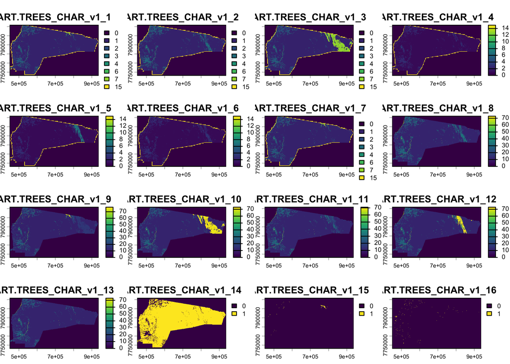

[output not shown]

[output not shown]

[output not shown]

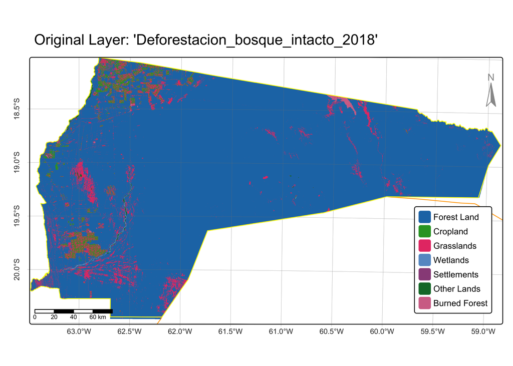

### Import Training Sample

```r
samples_raw     = read.csv(file.path(local_path, "Training-Samples", "glance_training.csv"))
samples_clean = samples_raw |>
    dplyr::select(Lon, Lat, Start_Year, End_Year, Veg_Modifier,
        Glance_Class_ID_level1, Glance_Class_ID_level2) |>
  dplyr::rename(
    longitude = Lon, latitude = Lat,
    level1 = Glance_Class_ID_level1,
    level2 = Glance_Class_ID_level2) |>
  dplyr::mutate(
    start_date = as.Date(paste(Start_Year, "01", "01", sep = "-")),
    end_date = as.Date(paste(End_Year, "01", "01", sep = "-"))) |>
    dplyr::mutate(veg_mod_clean = gsub('\\"', '', Veg_Modifier)) |>
  dplyr::mutate(
    has_wetland = grepl("Wetland|Mangrove|Riparian",veg_mod_clean,ignore.case=T),
    has_cropland = grepl("Cropland", veg_mod_clean, ignore.case = T),
    has_plantation = grepl("Plantation", veg_mod_clean, ignore.case = T)) |>
    dplyr::select(
        longitude, latitude, start_date, end_date, level1, level2,
        veg_mod_clean, has_wetland, has_cropland, has_plantation) |>
  dplyr::mutate(ipcc_code = case_when(
      has_wetland ~ 4,                                  # Mangrove & Riparian       >> Wetland
      level2 == 12 | has_cropland ~ 2,  # Agriculture                   >> Cropland
      level1 == 5 | has_plantation ~ 1, # Trees & Plantations       >> Forest Land
      level2 %in% c(10, 11, 13) ~ 3,        # Shrub, Moss, Grasses  >> Grassland
      level1 == 3 | grepl("Greenhouse", veg_mod_clean, ignore.case = T) ~ 5, # Developed >> Settlements
      level1 %in% c(1, 2, 4) ~ 6,               # Water, Ice, Barren        >> Other Land
      TRUE ~ 6)) |>                                         # Unclassified                  >> Other Land
  dplyr::mutate(ipcc_label = case_when(
      ipcc_code == 1 ~ "Forest Land",
      ipcc_code == 2 ~ "Cropland",
      ipcc_code == 3 ~ "Grassland",
      ipcc_code == 4 ~ "Wetland",
      ipcc_code == 5 ~ "Settlement",
      ipcc_code == 6 ~ "Other Land")) |>
  dplyr::mutate(ipcc_label = as.factor(ipcc_label)) |>
  dplyr::mutate(id = row_number()) |>
  dplyr::select(longitude, latitude, start_date, end_date, ipcc_code, ipcc_label, id)

samples_sf              = sf::st_as_sf(samples_clean, crs = 4326, coords = c("longitude", "latitude"))
samples_bolivia     = sf::st_intersection(samples_sf, aoi_country)  # n = 49,564 / 1,874,995
samples_bolivia     = sf::st_crop(samples_sf, st_bbox(aoi_country)) # trim artifacts
samples_charagua    = sf::st_intersection(samples_bolivia, aoi_cropper) # n = 4,772 / 1,874,995
samples_charagua    = sf::st_crop(samples_sf, st_bbox(aoi_cropper)) # trim artifacts

sf::st_write(samples_bolivia, file.path(local_path, "Training-Samples", "glance_training_bolivia.shp"), delete_dsn = T)
sf::st_write(samples_charagua, file.path(local_path, "Training-Samples", "glance_training_charagua.shp"), delete_dsn = T)
write.csv(samples_bolivia, file.path(local_path, "Training-Samples", "glance_training_bolivia.csv"), row.names = F)
write.csv(samples_charagua, file.path(local_path, "Training-Samples", "glance_training_charagua.csv"), row.names = F)
```

### Import Data Cube

```r
library(rgee)
ee_Initialize()

# Define your AOI in EPSG:4326 for GEE compatibility
aoi_ee <- sf_as_ee(aoi_cropper)  # Convert sf object to EE geometry

# Import GEE assets (these replace your local file imports)
landsat_2018 <- ee$Image('projects/murphys-deforisk/assets/LC08_001067_20180212')
landsat_2019 <- ee$Image('projects/murphys-deforisk/assets/LC08_001067_20190114')

# Clip to AOI (replaces terra::crop and mask operations)
landsat_2018_clip <- landsat_2018$clip(aoi_ee)
landsat_2019_clip <- landsat_2019$clip(aoi_ee)

# Extract individual bands (replaces your separate band file imports)
BLUE_2018 <- landsat_2018_clip$select('BLUE')
GREEN_2018 <- landsat_2018_clip$select('GREEN')
RED_2018 <- landsat_2018_clip$select('RED')
NIR08_2018 <- landsat_2018_clip$select('NIR08')
SWIR16_2018 <- landsat_2018_clip$select('SWIR16')
SWIR22_2018 <- landsat_2018_clip$select('SWIR22')
NDVI_2018 <- landsat_2018_clip$select('NDVI')

BLUE_2019 <- landsat_2019_clip$select('BLUE')
GREEN_2019 <- landsat_2019_clip$select('GREEN')
RED_2019 <- landsat_2019_clip$select('RED')
NIR08_2019 <- landsat_2019_clip$select('NIR08')
SWIR16_2019 <- landsat_2019_clip$select('SWIR16')
SWIR22_2019 <- landsat_2019_clip$select('SWIR22')
NDVI_2019 <- landsat_2019_clip$select('NDVI')


# capture from cloud for local processing:
ee_as_rast(image = BLUE_2018, region = aoi_ee, scale = 30, via = "gcs") ->      BLUE_2018
ee_as_rast(image = GREEN_2018, region = aoi_ee, scale = 30, via = "gcs") ->     GREEN_2018
ee_as_rast(image = RED_2018, region = aoi_ee, scale = 30, via = "gcs") ->       RED_2018
ee_as_rast(image = NIR08_2018, region = aoi_ee, scale = 30, via = "gcs") ->     NIR08_2018
ee_as_rast(image = SWIR16_2018, region = aoi_ee, scale = 30, via = "gcs") ->    SWIR16_2018
ee_as_rast(image = SWIR22_2018, region = aoi_ee, scale = 30, via = "gcs") ->    SWIR22_2018
ee_as_rast(image = NDVI_2018, region = aoi_ee, scale = 30, via = "gcs") ->      NDVI_2018

ee_as_rast(image = BLUE_2019, region = aoi_ee, scale = 30, via = "gcs") ->      BLUE_2019
ee_as_rast(image = GREEN_2019, region = aoi_ee, scale = 30, via = "gcs") ->     GREEN_2019
ee_as_rast(image = RED_2019, region = aoi_ee, scale = 30, via = "gcs") ->       RED_2019
ee_as_rast(image = NIR08_2019, region = aoi_ee, scale = 30, via = "gcs") ->     NIR08_2019
ee_as_rast(image = SWIR16_2019, region = aoi_ee, scale = 30, via = "gcs") ->    SWIR16_2019
ee_as_rast(image = SWIR22_2019, region = aoi_ee, scale = 30, via = "gcs") ->    SWIR22_2019
ee_as_rast(image = NDVI_2019, region = aoi_ee, scale = 30, via = "gcs") ->      NDVI_2019
```

### Stack Data Cube

```r
BLUE_2018       = terra::rast(file.path(local_path, "Bolivia-2018", "BLUE_2018.tif"))
BLUE_2019       = terra::rast(file.path(local_path, "Bolivia-2019", "BLUE_2019.tif"))
GREEN_2018  = terra::rast(file.path(local_path, "Bolivia-2018", "GREEN_2018.tif"))
GREEN_2019  = terra::rast(file.path(local_path, "Bolivia-2019", "GREEN_2019.tif"))
NIR08_2018  = terra::rast(file.path(local_path, "Bolivia-2018", "NIR08_2018.tif"))
NIR08_2019  = terra::rast(file.path(local_path, "Bolivia-2019", "NIR08_2019.tif"))
RED_2018        = terra::rast(file.path(local_path, "Bolivia-2018", "RED_2018.tif"))
RED_2019        = terra::rast(file.path(local_path, "Bolivia-2019", "RED_2019.tif"))
SWIR16_2018 = terra::rast(file.path(local_path, "Bolivia-2018", "SWIR16_2018.tif"))
SWIR16_2019 = terra::rast(file.path(local_path, "Bolivia-2019", "SWIR16_2019.tif"))
SWIR22_2018 = terra::rast(file.path(local_path, "Bolivia-2018", "SWIR22_2018.tif"))
SWIR22_2019 = terra::rast(file.path(local_path, "Bolivia-2019", "SWIR22_2019.tif"))
NDVI_2018       = terra::rast(file.path(local_path, "Bolivia-2018", "NDVI_2018.tif"))
NDVI_2019       =   terra::rast(file.path(local_path, "Bolivia-2019", "NDVI_2019.tif"))

DEM=terra::rast(file.path(local_path, "../", "DEM", "SRTMGL1-1ARCSEC-Bolivia.tif"))
names(DEM) = "Elevation"


BLUE_2018 = terra::resample(BLUE_2018, DEM) |> raster::raster()
BLUE_2019 = terra::resample(BLUE_2019, DEM) |> raster::raster()
GREEN_2018 = terra::resample(GREEN_2018, DEM) |> raster::raster()
GREEN_2019 = terra::resample(GREEN_2019, DEM) |> raster::raster()
RED_2018 = terra::resample(RED_2018, DEM) |> raster::raster()
RED_2019 = terra::resample(RED_2019, DEM) |> raster::raster()
SWIR16_2018 = terra::resample(SWIR16_2018, DEM) |> raster::raster()
SWIR16_2019 = terra::resample(SWIR16_2019, DEM) |> raster::raster()
SWIR22_2018 = terra::resample(SWIR22_2018, DEM) |> raster::raster()
SWIR22_2019 = terra::resample(SWIR22_2019, DEM) |> raster::raster()
NDVI_2018 = terra::resample(NDVI_2018, DEM) |> raster::raster()
NDVI_2019 = terra::resample(NDVI_2019, DEM) |> raster::raster()


STACK_2018 = raster::brick(BLUE_2018, GREEN_2018, RED_2018, NIR08_2018, SWIR16_2018, SWIR22_2018, NDVI_2018, DEM)
STACK_2019 = raster::brick(BLUE_2019, GREEN_2019, RED_2019, NIR08_2019, SWIR16_2019, SWIR22_2019, NDVI_2019, DEM)

raster::writeRaster(STACK_2018, format = "GTiff", overwrite = T,
    file.path(local_path, "STACK", "STACK_2018.tif"))
raster::writeRaster(STACK_2019, format = "GTiff", overwrite = T,
    file.path(local_path, "STACK", "STACK_2019.tif"))
```

### Image Classification

```r
# extract signatures
signatures_2018 = raster::extract(STACK_2018, samples, df=T) # watch for data formats
signatures_2019 = raster::extract(STACK_2019, samples, df=T) # watch for data formats

samples_signatures_2018 = dplyr::inner_join(signatures_2018, samples, by=c("ID"="id"))
samples_signatures_2019 = dplyr::inner_join(signatures_2019, samples, by=c("ID"="id"))

samples_signatures_2018$geometry <- NULL # set geometry to NULL for model training
samples_signatures_2019$geometry <- NULL # set geometry to NULL for model training

# Stratify-function to ensure class proportions are maintained in both train and test
stratified_partition <- function(data, group_col, train_ratio = 0.7) {
  split_data <- lapply(split(data, data[[group_col]]), function(df) {
    train_size <- max(1, floor(train_ratio * nrow(df)))
    train_idx <- sample(seq_len(nrow(df)), size = train_size)
    list(train = df[train_idx, ], test = df[-train_idx, ])
  })
  train_data <- do.call(rbind, lapply(split_data, `[[`, "train"))
  test_data <- do.call(rbind, lapply(split_data, `[[`, "test"))
  list(train = train_data, test = test_data)
  }

partitioned_data_2018 <- stratified_partition(samples_signatures_2018, group_col="ipcc_label", train_ratio=0.7)
partitioned_data_2019 <- stratified_partition(samples_signatures_2019, group_col="ipcc_label", train_ratio=0.7)

trainData_2018 = partitioned_data_2018$train
trainData_2019 = partitioned_data_2019$train
testData_2018  = partitioned_data_2018$test
testData_2019  = partitioned_data_2019$test
#table(trainData_2018$ipcc_label)
#table(testData_2018$ipcc_label)

# synthetic minotrity oversampling technique
trainData_2018 = performanceEstimation::smote(ipcc_label ~ .,data=trainData_2018,perc.over=30,perc.under=30)
trainData_2019 = performanceEstimation::smote(ipcc_label ~ .,data=trainData_2019,perc.over=30,perc.under=30)
testData_2018 = performanceEstimation::smote(ipcc_label ~ .,data=testData_2018,perc.over=30,perc.under=30)
testData_2019 = performanceEstimation::smote(ipcc_label ~ .,data=testData_2019,perc.over=30,perc.under=30)

# interpolate missing cloud pixels with class-median-normalization
trainData_2018 <- trainData_2018 |> group_by(ipcc_label) |> mutate(across(where(is.numeric),
    ~ ifelse(is.na(.), median(., na.rm = T), .))) |> ungroup()
trainData_2019 <- trainData_2019 |> group_by(ipcc_label) |> mutate(across(where(is.numeric),
    ~ ifelse(is.na(.), median(., na.rm = T), .))) |> ungroup()

testData_2018 <- testData_2018 |> group_by(ipcc_label) |> mutate(across(where(is.numeric),
    ~ ifelse(is.na(.), median(., na.rm = T), .))) |> ungroup()
testData_2019 <- testData_2019 |> group_by(ipcc_label) |> mutate(across(where(is.numeric),
    ~ ifelse(is.na(.), median(., na.rm = T), .))) |> ungroup()

# assign model variables
response  <- c("label")
predictors_2018 <- c("BLUE_2018", "GREEN_2018", "RED_2018", "NIR08_2018", "SWIR16_2018", "SWIR22_2018", "NDVI_2018", "DEM")
predictors_2019 <- c("BLUE_2019", "GREEN_2019", "RED_2019", "NIR08_2019", "SWIR16_2019", "SWIR22_2019", "NDVI_2019", "DEM")

# set training parameters
cv_regime <- caret::trainControl(
  method          = 'LGOCV',
  number          = 100,
  savePredictions = T,
  verboseIter     = F
  )

# train classifier
rf_model_2018 <- caret::train(
  ipcc_label~.,
  data = trainData_2018[, c(predictors_2018, "ipcc_label")], # drop ID var
  trControl = cv_regime,
  method    = "rf",
  metric    = 'Kappa',
  ntree     = 500,
  tuneLength= 6,
  importance= T
  )

rf_model_2019 <- caret::train(
  ipcc_label~.,
  data = trainData_2019[, c(predictors_2019, "ipcc_label")], # drop ID var
  trControl = cv_regime,
  method    = "rf",
  metric    = 'Kappa',
  ntree     = 500,
  tuneLength= 6,
  importance= T
  )
```

### Accuracy assessments[^1]

```r
rf_test_2018 <- predict(rf_model_2018, testData_2018)
print(rf_model_2018) # cv results
caret::confusionMatrix(rf_test_2018,testData_2018$label) # blind test results
```

[output not shown]

## Result

### Land Change Estimates

```r
LULC_2018 = terra::rast(local_path, "Classified", "LULC_2018.tif") |>
  terra::project(crs_project) |> terra::crop(aoi_project, mask=T) |> terra::trim()

LULC_2019 = terra::rast(local_path, "Classified", "LULC_2019.tif") |>
  terra::project(crs_project) |> terra::crop(aoi_project, mask=T) |> terra::trim()


code_dict <- data.frame(id = c(1, 2, 3, 4, 5, 6),
  ipcc_label = c("Forest Land", "Cropland", "Grasslands", "Wetlands", "Settlements", "Other Lands"))
levels(LULC_2018) <- code_dict
pixel_area_ha <- 0.088914  # 29.80124 x 29.80124 m² converted to hectares


compute_land_cover_summary <- function(aoi_project, rasters, pixel_area) {
  results <- list()
    if (terra::nrow(aoi_project) == 0) {
    stop("The provided SpatVector jurisdiction is empty.")
  }
  for (region in unique(aoi_project$name)) {
    for (year in names(rasters)) {
      cropped_raster <- terra::crop(
        rasters[[year]],
        aoi_project[aoi_project$name == region, ],
        mask = TRUE
      )
      if (terra::ncell(cropped_raster) == 0) {
        warning(paste("Cropped raster for", region, year, "is empty. Skipping."))
        next
      }
      freq <- terra::freq(cropped_raster)
      freq$area_ha <- freq$count * pixel_area
      freq$percentage <- (freq$area_ha / sum(freq$area_ha)) * 100
      freq$region <- region
      freq$year <- year
      results[[paste(region, year, sep = "_")]] <- freq
    }
  }
  return(do.call(rbind, results))
}

# Organize rasters into a named list
rasters <- list(
  "2018" = LULC_2018,
  "2019" = LULC_2019
)

# Compute land cover summary
land_cover_summary <- compute_land_cover_summary(aoi_project, rasters, pixel_area_ha)
write.csv(land_cover_summary, file.path(local_path, "Estimates", "land_change_estimates.csv", row.names = F)
land_cover_summary
```

[output not shown]

## Conclusions

### Runtime Log

```r
sf::st_drivers()
```

```
# A tibble: 53 × 7
   name           long_name                write copy  is_raster is_vector vsi
   <chr>          <chr>                    <lgl> <lgl> <lgl>     <lgl>     <lgl>
 1 OGR_GRASS      GRASS Vectors (5.7+)     FALSE FALSE FALSE     TRUE      FALSE
 2 MEM            In Memory raster, vecto… TRUE  FALSE TRUE      TRUE      FALSE
 3 PCIDSK         PCIDSK Database File     TRUE  FALSE TRUE      TRUE      TRUE
 4 PDS4           NASA Planetary Data Sys… TRUE  TRUE  TRUE      TRUE      TRUE
 5 VICAR          MIPL VICAR file          TRUE  TRUE  TRUE      TRUE      TRUE
 6 PDF            Geospatial PDF           TRUE  TRUE  TRUE      TRUE      TRUE
 7 MBTiles        MBTiles                  TRUE  TRUE  TRUE      TRUE      TRUE
 8 EEDA           Earth Engine Data API    FALSE FALSE FALSE     TRUE      FALSE
 9 OGCAPI         OGCAPI                   FALSE FALSE TRUE      TRUE      TRUE
10 ESRI Shapefile ESRI Shapefile           TRUE  FALSE FALSE     TRUE      TRUE
# ℹ 43 more rows
```

```r
sf::sf_extSoftVersion()
```

```
          GEOS           GDAL         proj.4 GDAL_with_GEOS     USE_PROJ_H
      "3.14.1"       "3.12.0"        "9.7.1"         "true"         "true"
          PROJ
       "9.7.1"
```

```r
# Autosave records in runtime log folder
writeLines(capture.output(devtools::session_info()),
           paste0("./Runtime Log/runtime_log_", format(Sys.time(), "%Y%m%d_%H%M%S"), ".txt"))
```

## Footnotes

[^1]: Please note that model performance metrics differ slightly with each runtime due to Monte Carlo resampling and the number of randomForest decision trees. This is to say that accuracy results in the chunk below may not be precisely matching the in-text reporting here if a new run has been implemented locally on your machine.